# Edyta Pszczolkowska (ID 435022) - Clustering using kmeans and CLARA

The dataset contains data about customers of a food store which sells in stationary shops and also via internet and catalog. I will perform 2 different algorithms on the dataset: kmeans, CLARA. Such a method can be used for customers segmentation - based on characteristics of customers in particular clusters, we can summarize their traits and adjust the offer to their needs and expectations.

The dataset contains of following variables:

“Income” “Last_purchase” “MntWines” - amount spent on wine, “MntFruits” - amount spent on fruits, “MntMeatProducts” - amount spent on meat, “MntFishProducts” - amount spent on fish products, “MntSweetProducts” - amount spent on sweets, “Purchases_with_discount”, “NumWebPurchases”, “NumCatalogPurchases”, “NumStorePurchases”, “NumWebVisitsMonth”, “Complain” - binary variable, “age”, “partner” - binary variable, “kids together”

```r
knitr::opts_chunk$set(warning = FALSE, message = FALSE)
```

```r
# LOADING DATA AND NECESSARY PACKAGES

data <- read.csv("marketing_data.csv")


# install.packages("factoextra")
# install.packages("flexclust")
# install.packages("fpc")
# install.packages("clustertend")
# install.packages("cluster")
# install.packages("ClusterR")
# install.packages("pdp")
library(factoextra)
library(flexclust)
library(fpc)
library(clustertend)
library(cluster)
library(ClusterR)
library(pdp)
```

```r
#Data preparation

#deleting columns I don't need

data$AcceptedCmp1 <- NULL
data$AcceptedCmp2 <- NULL
data$AcceptedCmp3 <- NULL
data$AcceptedCmp4 <- NULL
data$AcceptedCmp5 <- NULL
data$MntGoldProds <- NULL
data$Response <- NULL
data$Dt_Customer <- NULL
data$Country <- NULL





#renaming columns
colnames(data)[1] <- "ID"
colnames(data)[colnames(data) == "Recency"] <- "Last_purchase"
colnames(data)[colnames(data) == "NumDealsPurchases"] <- "Purchases_with_discount"





#Instead of birth year I prefer age

data$age <- 2021 - data$Year_Birth

data$Year_Birth <- NULL

table(data$age)
```

```
##
##  25  26  27  28  29  30  31  32  33  34  35  36  37  38  39  40  41  42  43  44
##   2   5   3   5  13  15  18  30  29  27  42  32  38  42  45  39  39  53  77  52
##  45  46  47  48  49  50  51  52  53  54  55  56  57  58  59  60  61  62  63  64
##  89  83  69  74  79  87  77  71  51  44  50  74  42  45  44  36  49  51  53  43
##  65  66  67  68  69  70  71  72  73  74  75  76  77  78  80  81 121 122 128
##  55  49  50  35  52  43  29  30  21  16  16   8   7   7   1   1   1   1   1
```

```r
# customers aged 121, 122, 128 - doesn't look like reliable data :(

data <- data[!(data$age=="121" | data$age=="122" | data$age=="128"), ]





table(data$Education)
```

```
##
##   2n Cycle      Basic Graduation     Master        PhD
##        201         54       1127        370        485
```

```r
#As it is impossible to know what the creator of the dataset meant by those values, the column will be deleted to not introduce misleading info

data$Education <- NULL





table(data$Marital_Status)
```

```
##
##   Absurd    Alone Divorced  Married   Single Together    Widow     YOLO
##        2        3      231      864      479      579       77        2
```

```r
#let's divide customers into two groups - in relationship (married, together) noted by "1"  and other noted by "0"

data$partner <- ifelse(data$Marital_Status == "Married" | data$Marital_Status == "Together", 1, 0)

data$Marital_Status <- NULL






#converting variable "INCOME" to numeric
data$Income <- substr(data$Income, 2, nchar(data$Income))

data$Income <-   sapply(data$Income, function(v) {as.numeric(gsub("\\,","", (v)))})

class(data$Income)
```

```
## [1] "numeric"
```

```r
summary(data$Income)
```

```
##    Min. 1st Qu.  Median    Mean 3rd Qu.    Max.    NA's
##    1730   35246   51373   52237   68487  666666      24
```

```r
data <- na.omit(data)

#serious outlier in income

data <- data[!(data$Income == "666666"), ]




#rearranging columns - I prefer number of children overall rather than with division for teens and younger

data$kidstogether <- data$Kidhome + data$Teenhome

data$Kidhome <- NULL
data$Teenhome <- NULL
```

```r
##################################################################################
#Let's play a game...


cluster <- data[2:17]

#Scaling data - we have different variables

cluster_z <- as.data.frame(lapply(cluster, scale))

# Compute Hopkins statistic for data
get_clust_tendency(cluster_z, 2, graph= FALSE)
```

```
## $hopkins_stat
## [1] 0.8799351
##
## $plot
## NULL
```

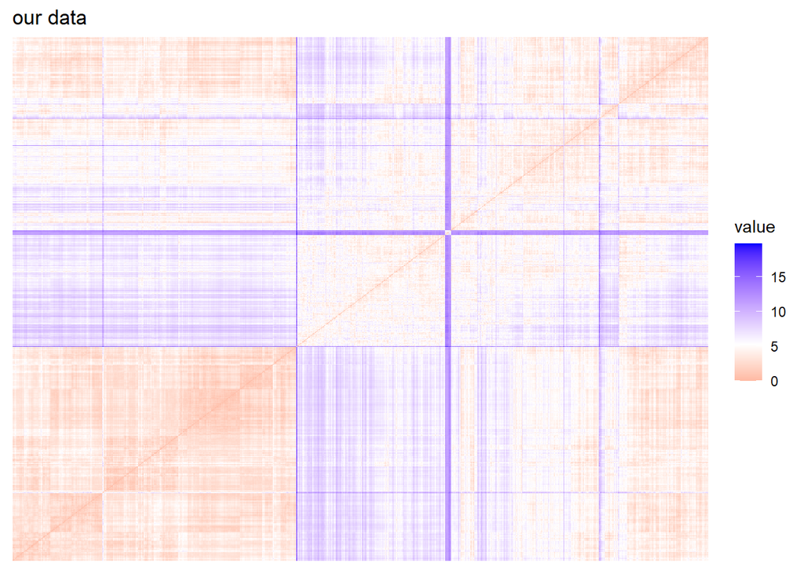

```r
# If the value of Hopkins statistic is close to 1, then we can reject the null hypothesis and conclude
#that the dataset D is significantly a clusterable data. The obtained value = 0,8799 - good news.


# Plotting the Ordered Dissimilarity Matrix helps also to judge whether dataset is clusterable.
# We can assess it visually based on the graph - when blocks of colors are visible the dataset is good for clustering.

di<-dist(cluster_z, method="euclidean")
fviz_dist(di, show_labels = FALSE)+ labs(title="our data")
```

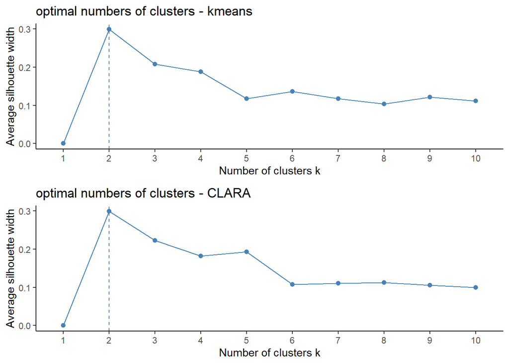

```r
# CHECKING PROPER NUMBER OF CLUSTERS BASED ON SILHOUETTE INDEX




a <- fviz_nbclust(cluster_z, FUNcluster = kmeans, method = "silhouette") + theme_classic() + ggtitle("optimal numbers of clusters - kmeans")
b <- fviz_nbclust(cluster_z, FUNcluster = cluster::clara, method = "silhouette") + theme_classic() + ggtitle("optimal numbers of clusters - CLARA")


grid.arrange(a,b,  ncol=1)
```